# Week 4

### Monday

```python
import matplotlib.pyplot as plt
```

```python
def myfun(arg1,arg2=0):

    if arg2==0:
        return arg1
    else:
        return arg1 - arg2
```

```python
myfun(2)
```

```
2
```

```python
myfun(4,5)
```

```
-1
```

```python
def myfun2(arg1,arg2=0):
    return arg1 - arg2
```

```python
myfun2(2)
```

```
2
```

```python
myfun2(4,5)
```

```
-1
```

Define a function that takes a list of integers as its argument, and returns the product of the second and last element of the list. (You can assume that the list has at least 3 arguments)

```python
def f(mylist):
    return mylist[1]*mylist[-1] # or     return mylist[1]*mylist[len(mylist)-1]
```

Given the nested list `mylist=[[1,2,11],[3,4,7],[5,6,13]]`, write the code to get the elements `[1,2]`, and the list `[3,5]`, and `[3,7]`

```python
mylist=[[1,2,11],[3,4,7],[5,6,13]]
```

```python
mylist[0][:2]
```

```
[1, 2]
```

```python
[mylist[1][0], mylist[2][0]]
```

```
[3, 5]
```

```python
[mylist[1][0],mylist[1][2]]
```

```
[3, 7]
```

```python
mylist[1][::2]
```

```
[3, 7]
```

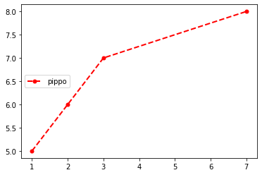

```python
x=[1,2,3,7]
y=[5,6,7,8]
plt.plot(x,y,'r.--',linewidth=2,ms=10,label='pippo')
plt.legend(loc='center left')
plt.show()
```

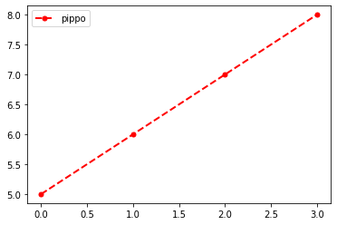

```python
plt.plot(y,'r.--',linewidth=2,ms=10) # colors k,b,y,g,r,m,c; #linestyle :,-,--; #marker o,.,s,*,+,^,v,<,>
plt.legend(['pippo'])
plt.show()
```

## List comprehension

**Ex** write the code to create a list of numbers from 0 to 5 with a step of 0.5

```python
mylist=list(range(0,11))
print(mylist)
```

```
[0, 1, 2, 3, 4, 5, 6, 7, 8, 9, 10]
```

```python
l=[]
for k in range(11):
    l.append(k/2)
l
```

```
[0.0, 0.5, 1.0, 1.5, 2.0, 2.5, 3.0, 3.5, 4.0, 4.5, 5.0]
```

more concise way to build a list: **list comprehension**

```python
mylist=[k/2 for k in range(11)]
print(mylist)
```

```
[0.0, 0.5, 1.0, 1.5, 2.0, 2.5, 3.0, 3.5, 4.0, 4.5, 5.0]
```

```python
mylist=[greeting+', dear '+name for greeting in ['Hi','Hello'] for name in ['Xinyi','Simone','Erin'] ]
print(mylist)
```

```
['Hi, dear Xinyi', 'Hi, dear Simone', 'Hi, dear Erin', 'Hello, dear Xinyi', 'Hello, dear Simone', 'Hello, dear Erin']
```

```python
mylist=[]
for greeting in ['Hi','Hello']:
    for name in ['Xinyi','Simone','Erin']:
        mylist.append(greeting+', dear '+name)
print(mylist)
```

```
['Hi, dear Xinyi', 'Hi, dear Simone', 'Hi, dear Erin', 'Hello, dear Xinyi', 'Hello, dear Simone', 'Hello, dear Erin']
```

**ex** build `list` with the squares of all even numbers in $[0,20)$

```python
mylist=[]

for i in range(20):
    if i%2==0:
        mylist.append(i**2)

print(mylist)
```

```
[0, 4, 16, 36, 64, 100, 144, 196, 256, 324]
```

```python
mylist=[i**2 for i in range(20) if i%2==0]
print(mylist)
```

```
[0, 4, 16, 36, 64, 100, 144, 196, 256, 324]
```

```python
def cuberoot(n):
    return pow(n,1/3)

mylist=[cuberoot(k) for k in range(-5,6)]
print(mylist)
```

```
[(0.8549879733383486+1.480882609682364j), (0.7937005259840999+1.3747296369986024j), (0.7211247851537043+1.2490247664834064j), (0.6299605249474367+1.0911236359717214j), (0.5000000000000001+0.8660254037844386j), 0.0, 1.0, 1.2599210498948732, 1.4422495703074083, 1.5874010519681994, 1.7099759466766968]
```

**Ex** plot $y=x^3+2x+3$ in $[0,1]$ using 100 steps . Use list comprehension to build `x` and `y`

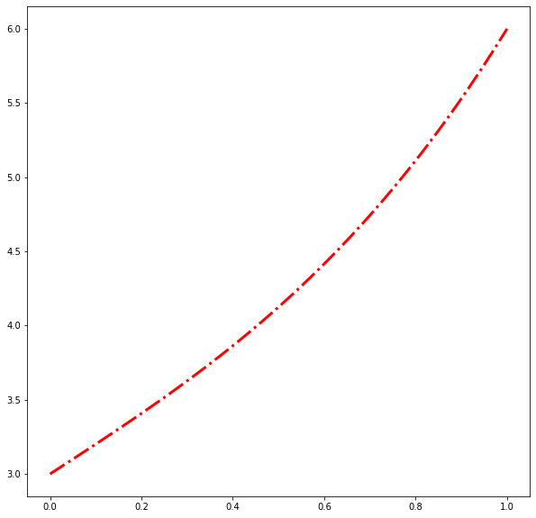

```python
n=100 # number of steps

x=[k/n for k in range(n+1)]
y=[k**3+2*k+3 for k in x]

plt.figure(figsize=(10,10))
plt.plot(x,y,'r-.',lw=3)
plt.show()
```

**Ex.** plot a circle with radius 2, center (0,0)

use the parametric eq. for a circle: $x=2\ \cos(t), \quad y=2\ \sin(t)$ for $t$ in $[0,2\pi)$

```python
from math import pi,sin,cos
```

```python
n=1000 # number of steps

t=[2*pi*k/n for k in range(n+1)] # creating n steps in which interval
x=[2*cos(z) for z in t]
y=[2*sin(z) for z in t]
```

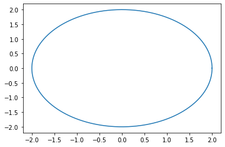

```python
plt.plot(x,y)
plt.show()
```

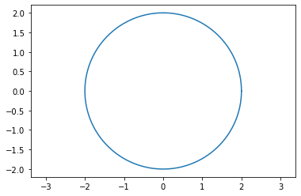

```python
plt.plot(x,y)
plt.axis('equal')
plt.show()
```

`isprime(n)`

**Ex** produce the zig-zag **plot**, add your first last name in the title, and post it on discord in the `zigzag-pattern` channel

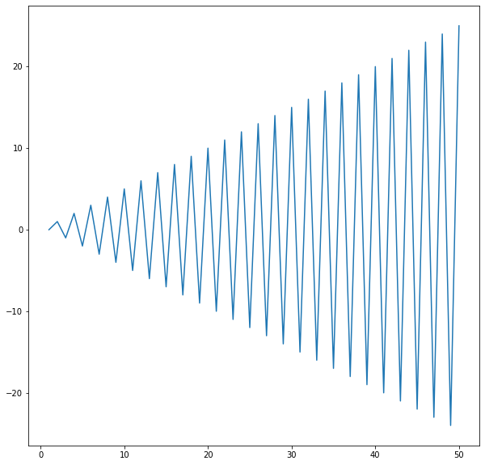

`isprime(n)`: given a number `n` returns `True` if `n` is prime, `False` otherwise

- given `n` loop through `[2,n)` with `i` (range, for loop) (to improve this you could look only in the range `[2,sqrt(n)]`)
- if `n%i==0` -> number is not prime (return `False`)
- otherwise the number is prime

## subplots

`plt.subplot(r,c,p)` # r: row, c:column, p:position

```python
from math import pi,sin,cos,tan,atan
N=100
x=[2*pi*k/N for k in range(N)]
s=[sin(k) for k in x]
c=[cos(k) for k in x]
```

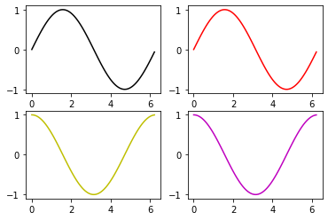

```python
plt.subplot(2,2,1)
plt.plot(x,s,'k')

plt.subplot(2,2,2)
plt.plot(x,s,'r')

plt.subplot(2,2,3)
plt.plot(x,c,'y')

plt.subplot(2,2,4)
plt.plot(x,c,'m')

plt.show()
```